> **Tip**: Welcome to the Investigate a Dataset project! You will find tips in quoted sections like this to help organize your approach to your investigation. Before submitting your project, it will be a good idea to go back through your report and remove these sections to make the presentation of your work as tidy as possible. First things first, you might want to double-click this Markdown cell and change the title so that it reflects your dataset and investigation.

# Project: Investigate a TMDB movie Dataset

- Introduction
- Data Wrangling
- Exploratory Data Analysis
- Conclusions

# INTRODUCTION

In this project we are asked to Investigate a dataset.From the provided options I have selected the dataset "TMDb movie dataset".

The questions that we will be analysing are

1.Which year has the highest release of movies?

2.Movie with Largest And Lowest Earned Revenue?

3.What are the properties that are associated with films with high revenues?

```python
import numpy as np
import pandas as pd
import matplotlib.pyplot as plt
import seaborn as sns
% matplotlib inline
```

## Data Wrangling

### General Properties

Let us look through the entire dataset by looking through each columns in the dataset.

Then perform some datacleaning process before performing analysis on the data

```python
df=pd.read_csv('tmdb-movies.csv')
```

find the number of rows and columms

```python
df.shape
```

```
(10866, 21)
```

Number of rows=10866

Number of columns=21

```python
df.info()
```

```
<class 'pandas.core.frame.DataFrame'>
RangeIndex: 10866 entries, 0 to 10865
Data columns (total 21 columns):
id                      10866 non-null int64
imdb_id                 10856 non-null object
popularity              10866 non-null float64
budget                  10866 non-null int64
revenue                 10866 non-null int64
original_title          10866 non-null object
cast                    10790 non-null object
homepage                2936 non-null object
director                10822 non-null object
tagline                 8042 non-null object
keywords                9373 non-null object
overview                10862 non-null object
runtime                 10866 non-null int64
genres                  10843 non-null object
production_companies    9836 non-null object
release_date            10866 non-null object
vote_count              10866 non-null int64
vote_average            10866 non-null float64
release_year            10866 non-null int64
budget_adj              10866 non-null float64
revenue_adj             10866 non-null float64
dtypes: float64(4), int64(6), object(11)
memory usage: 1.7+ MB
```

from the above step it can be clearly seen that the columns present in the dataset are

1.imdb_id

2.popularity

3.budget

4.revenue

5.original_title

6.cast

7.homepage

8.director

9.tagline

10.keywords

11.overview

12.runtime

13.genres

14.production_companies

15.release_date

16.vote_count

17.vote_average

18.release_year

19.budget_adj

20.revenue_adj

### Data Cleaning

Hence before dropping the null values let us drop the columns that are not required for this analysis.

The columns that we can drop are

1.imdb_id

2.homepage

3.tagline

4.keywords

6.overview

7.runtime

8.production_companies

```python
df.drop(['imdb_id','homepage','tagline','keywords','overview','runtime','production_companies'],axis=1,inplace=True)
```

```python
df.info()
```

```
<class 'pandas.core.frame.DataFrame'>
RangeIndex: 10866 entries, 0 to 10865
Data columns (total 14 columns):
id                10866 non-null int64
popularity        10866 non-null float64
budget            10866 non-null int64
revenue           10866 non-null int64
original_title    10866 non-null object
cast              10790 non-null object
director          10822 non-null object
genres            10843 non-null object
release_date      10866 non-null object
vote_count        10866 non-null int64
vote_average      10866 non-null float64
release_year      10866 non-null int64
budget_adj        10866 non-null float64
revenue_adj       10866 non-null float64
dtypes: float64(4), int64(5), object(5)
memory usage: 1.2+ MB
```

When we look at the dataset after dropping the columns it is pretty clear that the columns that were unnecessary for data

analysis was removed successfully.

But it can be seen that some columns has null values and there are duplicated rows also.

```python
#check for duplicates
df.duplicated()
```

[output not shown]

[output cut: 47 more lines]

```python
#remove the duplicates
df.drop_duplicates(inplace=True)
```

```python
df.shape
```

```
(10865, 14)
```

It can be seen that the number of rows has been decreased thereby indicating that the duplicated rows has been removed.

```python
#fill the null values with zero
df.fillna(0)
```

[output not shown]

10865 rows × 14 columns

```python
#check if any more columns have null value
df.info()
```

```
<class 'pandas.core.frame.DataFrame'>
Int64Index: 10865 entries, 0 to 10865
Data columns (total 14 columns):
id                10865 non-null int64
popularity        10865 non-null float64
budget            10865 non-null int64
revenue           10865 non-null int64
original_title    10865 non-null object
cast              10789 non-null object
director          10821 non-null object
genres            10842 non-null object
release_date      10865 non-null object
vote_count        10865 non-null int64
vote_average      10865 non-null float64
release_year      10865 non-null int64
budget_adj        10865 non-null float64
revenue_adj       10865 non-null float64
dtypes: float64(4), int64(5), object(5)
memory usage: 1.2+ MB
```

```python
df.describe()
```

|  | id | popularity | budget | revenue | vote_count | vote_average | release_year | budget_adj | revenue_adj |
| --- | --- | --- | --- | --- | --- | --- | --- | --- | --- |
| count | 10865.000000 | 10865.000000 | 1.086500e+04 | 1.086500e+04 | 10865.000000 | 10865.000000 | 10865.000000 | 1.086500e+04 | 1.086500e+04 |
| mean | 66066.374413 | 0.646446 | 1.462429e+07 | 3.982690e+07 | 217.399632 | 5.975012 | 2001.321859 | 1.754989e+07 | 5.136900e+07 |
| std | 92134.091971 | 1.000231 | 3.091428e+07 | 1.170083e+08 | 575.644627 | 0.935138 | 12.813260 | 3.430753e+07 | 1.446383e+08 |
| min | 5.000000 | 0.000065 | 0.000000e+00 | 0.000000e+00 | 10.000000 | 1.500000 | 1960.000000 | 0.000000e+00 | 0.000000e+00 |
| 25% | 10596.000000 | 0.207575 | 0.000000e+00 | 0.000000e+00 | 17.000000 | 5.400000 | 1995.000000 | 0.000000e+00 | 0.000000e+00 |
| 50% | 20662.000000 | 0.383831 | 0.000000e+00 | 0.000000e+00 | 38.000000 | 6.000000 | 2006.000000 | 0.000000e+00 | 0.000000e+00 |
| 75% | 75612.000000 | 0.713857 | 1.500000e+07 | 2.400000e+07 | 146.000000 | 6.600000 | 2011.000000 | 2.085325e+07 | 3.370173e+07 |
| max | 417859.000000 | 32.985763 | 4.250000e+08 | 2.781506e+09 | 9767.000000 | 9.200000 | 2015.000000 | 4.250000e+08 | 2.827124e+09 |

From the above we can see that many rows has budget value as 0 which when included in the analysis process may result in wrong answer .

Hence drop all the rows that have either revenue or budget as zero.

```python
# Get names of indexes for which column revenue has value 0
indexNames = df[ df['revenue'] == 0 ].index
# Delete these row indexes from dataFrame
df.drop(indexNames , inplace=True)
indexNames1 = df[ df['budget'] == 0 ].index
# Delete these row indexes from dataFrame
df.drop(indexNames1 , inplace=True)
```

## Exploratory Data Analysis

### Research Question 1(What is the highest budget of all)

```python
#find the various description about the budget column
df['budget'].describe()
```

```
count    3.854000e+03
mean     3.720370e+07
std      4.220822e+07
min      1.000000e+00
25%      1.000000e+07
50%      2.400000e+07
75%      5.000000e+07
max      4.250000e+08
Name: budget, dtype: float64
```

### Research Question 2(What is the highest revenue of all)

```python
#find the various description about the revenue column
df['revenue'].describe()
```

```
count    3.854000e+03
mean     1.076866e+08
std      1.765393e+08
min      2.000000e+00
25%      1.360003e+07
50%      4.480000e+07
75%      1.242125e+08
max      2.781506e+09
Name: revenue, dtype: float64
```

### Research Question 3(What is the min vote_count of all)

```python
#find the various description about the vote_count column
df['vote_count'].describe()
```

```
count    3854.000000
mean      527.720291
std       879.956821
min        10.000000
25%        71.000000
50%       204.000000
75%       580.000000
max      9767.000000
Name: vote_count, dtype: float64
```

### Research Question 4 (Which year has the highest release of movies?)

```python
#Obtain the first five rows
df.groupby('release_date').count()['original_title'].head()
```

[output not shown]

It can be seen that the date is not in the correct format hence change the date format

```python
#To convert format
df['release_date']=pd.to_datetime(df['release_date'])
df['release_date'].head()
```

```
0   2015-06-09
1   2015-05-13
2   2015-03-18
3   2015-12-15
4   2015-04-01
Name: release_date, dtype: datetime64[ns]
```

```python
#group by the year to find the count
data=df.groupby('release_year').count()['id']
print(data.tail())
```

```
release_year
2011    199
2012    158
2013    180
2014    165
2015    160
Name: id, dtype: int64
```

Plot the findings in a bar chart using matplotlib

```
Text(0,0.5,'Number Of Movies')
```

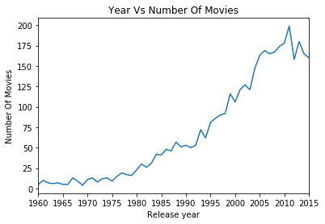

```python
data=df.groupby('release_year').count()['id'].plot(xticks = np.arange(1960,2016,5))

plt.title("Year Vs Number Of Movies")
plt.xlabel('Release year')
plt.ylabel('Number Of Movies')
```

### Research Question 5 ( Movie with Largest And Lowest Earned Revenue?)

```python
#define a function to find the index with minimum and maximum value
def min_max(x):
#use the function 'idmin' to find the index of Lowest revenue movie.
    min_index = df[x].idxmin()
#use the function 'idmax' to find the index of Highest revenue movie.
    high_index = df[x].idxmax()
#Get the name of the movie based on index value
    df_min=df['original_title'][min_index]
    df_max=df['original_title'][high_index]
    print ("Movie Which Has Lowest Revenue is ",df_min)
    print ("Movie Which Has Highest Revenue is ",df_max)
#call the function
min_max('revenue')
```

```
Movie Which Has Lowest Revenue is  Shattered Glass
Movie Which Has Highest Revenue is  Avatar
```

Let us plot the top 10 grossing movies in a graph.

```python
#sort the 'revenue' column in decending order and store it in the new dataframe.
asc = pd.DataFrame(df['revenue'].sort_values(ascending = False))
asc['original_title'] = df['original_title']
```

```
Text(0.5,1,'Highest grossing movies')
```

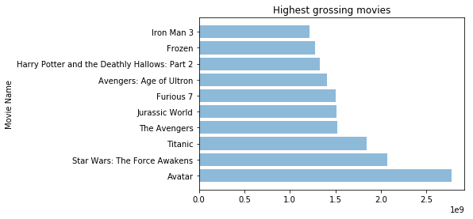

```python
#slice the top 10 movies from the asc dataframe
extract=asc.iloc[:10]
#create a bar chart to show the comparsion
y_pos = np.arange(len(extract))
performance = extract['revenue']
plt.barh(y_pos, performance, align='center', alpha=0.5)
plt.yticks(y_pos, extract['original_title'])
plt.ylabel('Movie Name')
plt.title('Highest grossing movies')
```

# Reserch Question 6(What are the properties that are associated with films with high revenues?

To answer this question let us compare various factors or the columns that may influence revenue. The factors may be 1.Budget of the film 2.vote_average 3.popularity

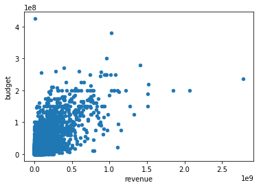

```python
#create scatterplots to find corelation between each of the factors and revenue
df.plot(x='revenue',y='budget',kind='scatter')
```

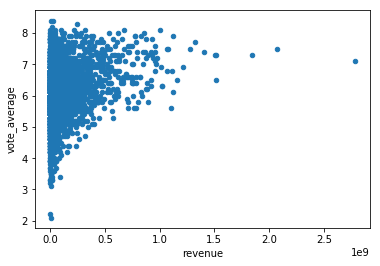

```python
#create scatterplots to find corelation between each of the factors and revenue
df.plot(x='revenue',y='vote_average',kind='scatter')
```

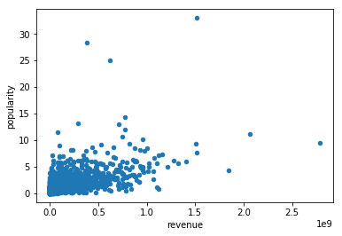

```python
#create scatterplots to find corelation between each of the factors and revenue
df.plot(x='revenue',y='popularity',kind='scatter')
```

```python
#We can find the corelaion values between each factor and determine which factors affect revenue
df.corr()
```

|  | id | popularity | budget | revenue | vote_count | vote_average | release_year | budget_adj | revenue_adj |
| --- | --- | --- | --- | --- | --- | --- | --- | --- | --- |
| id | 1.000000 | 0.140274 | -0.068388 | -0.040848 | 0.069929 | 0.007703 | 0.506720 | -0.145814 | -0.115453 |
| popularity | 0.140274 | 1.000000 | 0.481107 | 0.629305 | 0.788293 | 0.288988 | 0.170276 | 0.440049 | 0.561746 |
| budget | -0.068388 | 0.481107 | 1.000000 | 0.704009 | 0.585866 | 0.037429 | 0.237940 | 0.964008 | 0.560647 |
| revenue | -0.040848 | 0.629305 | 0.704009 | 1.000000 | 0.764113 | 0.206847 | 0.121388 | 0.674335 | 0.905005 |
| vote_count | 0.069929 | 0.788293 | 0.585866 | 0.764113 | 1.000000 | 0.351291 | 0.196837 | 0.533281 | 0.666495 |
| vote_average | 0.007703 | 0.288988 | 0.037429 | 0.206847 | 0.351291 | 1.000000 | -0.094828 | 0.049090 | 0.242319 |
| release_year | 0.506720 | 0.170276 | 0.237940 | 0.121388 | 0.196837 | -0.094828 | 1.000000 | 0.083306 | -0.099447 |
| budget_adj | -0.145814 | 0.440049 | 0.964008 | 0.674335 | 0.533281 | 0.049090 | 0.083306 | 1.000000 | 0.593280 |
| revenue_adj | -0.115453 | 0.561746 | 0.560647 | 0.905005 | 0.666495 | 0.242319 | -0.099447 | 0.593280 | 1.000000 |

Plot 1: Budget vs Revenue

The revenues do increase slightly at higher levels but the number of movies with high budgets seem scarce.

Correlation = 0.70

The revenue seems to be increasing with popularity. We can say that if the popularity of movie is high then the revenue of the movie may be high.

Correlation = 0.62

The correlation between revenue and vote average is 0.2069. So vote average is not highly related to the revenue.

## Submitting your Project

> Before you submit your project, you need to create a .html or .pdf version of this notebook in the workspace here. To do that, run the code cell below. If it worked correctly, you should get a return code of 0, and you should see the generated .html file in the workspace directory (click on the orange Jupyter icon in the upper left).

> Alternatively, you can download this report as .html via the **File** > **Download as** submenu, and then manually upload it into the workspace directory by clicking on the orange Jupyter icon in the upper left, then using the Upload button.

> Once you've done this, you can submit your project by clicking on the "Submit Project" button in the lower right here. This will create and submit a zip file with this .ipynb doc and the .html or .pdf version you created. Congratulations!

Movie Which Has Lowest Revenue is Shattered Glass

Movie Which Has Highest Revenue is Avatar

Movies with higher budgets have shown a increase in the revenues.

Movies that are also popular show increase in revenues

# Limitations

I am not sure that if the correlation is 100 percent true, but it shows us that we have high probability of making high

profits if we had similar characteristics as such.

But it is pretty evident that if movie is made with higher budget then it gives higher revenue.

During the data cleaning process, it was found that several rows have budget values is zero , hence

we remove such rows so that it does not affect the analysis process

```python
from subprocess import call
call(['python', '-m', 'nbconvert', 'Investigate_a_Dataset.ipynb'])
```

```
0
```